# Human Actvitiy Recognition

Joben Ilagan

19 October 2015

Six young health participants were asked to perform one set of 10 repetitions of the Unilateral Dumbbell Biceps Curl in five different fashions:

- **Class A**: Exactly according to the specification,
- **Class B**: Throwing the elbows to the front,
- **Class C**: Lifting the dumbbell only halfway,
- **Class D**: Lowering the dumbbell only halfway, and
- **Class E**: Throwing the hips to the front.

They measured their movements, and the data can be found here: http://groupware.les.inf.puc-rio.br/har.

Read more: http://groupware.les.inf.puc-rio.br/har#sbia_paper_section#ixzz3oyROG8S5

The goal of this project is to predict the manner in which they did the exercises, that is, whether correctly (Class A) or incorrectly (Classes B to E). This is the **classe** variable in the training set.

The other variables may be used for the prediction.

```r
library(caret)
library(randomForest)
```

```r
library(ggplot2)
library(gbm)
library(plyr)

training<-read.csv("pml-training.csv")
testing<-read.csv("pml-testing.csv")
pctTraining<-dim(training)[1] / (dim(training)[1] + dim(testing)[1])
pctTesting<-dim(testing)[1] / (dim(training)[1] + dim(testing)[1])
```

## Data Cleansing and Exploratory Data Analysis

**Note**

*After going through several trials, I realized that I needed to reduce the data further just to speed things up. With the data as-is, the training steps couldn’t even finish at all. There are a number of columns that don’t contain data, so I decided to take those out.*

Determine which columns have all blanks and take them out.

```r
isemptycol.training<-sapply(1:ncol(training), function(x) all(training[x]=='' || is.na(training[x])))
# Make sure that the training data also has the same characteristics
isemptycol.testing<-sapply(1:ncol(testing), function(x) all(testing[x]=='' || is.na(testing[x])))
all(isemptycol.training==isemptycol.testing)
```

```
## [1] TRUE
```

```r
# Remove almost the same columns from both training and testing data sets.
# Note that the last column of training is 'classe' and that of testing is 'problem_id'
training<-training[!isemptycol.training]
testing<-testing[!isemptycol.testing]

# Remove columns 1-7 ("X","user_name","raw_timestamp_part_1","raw_timestamp_part_2",
# "cvtd_timestamp","new_window","num_window") as these won't impact prediction
training<-training[-1:-7]
testing<-testing[-1:-7]
```

The training set has **19,622** rows and **53** columns. The training set has **99.9%** of the total data.

The testing set has **20** rows and **53** columns. The testing set has **0.1018%** of the total data.

We can therefore extract more data from the training set for cross-validation and (internal) testing before using the actual testing data set (pml-testing.csv) at the end of the exercise.

The variable *classe* has five values as shown here:

```r
levels(training$classe)
```

```
## [1] "A" "B" "C" "D" "E"
```

```r
averages<-colnames(training[grepl('avg',colnames(training))])
averages
```

```
## character(0)
```

```r
set.seed(12345);
inTraining<-createDataPartition(training$classe,p=0.6,list=FALSE)
trainingML<-training[inTraining,]
testingML<-training[-inTraining,]
```

Training and Testing should now have a 60-40 mix.

```r
pctTrainingML<-dim(trainingML)[1] / (dim(trainingML)[1] + dim(testingML)[1])
pctTestingML<-dim(testingML)[1] / (dim(trainingML)[1] + dim(testingML)[1])
pctTrainingML
```

```
## [1] 0.6001427
```

```r
pctTestingML
```

```
## [1] 0.3998573
```

### Initial Plots

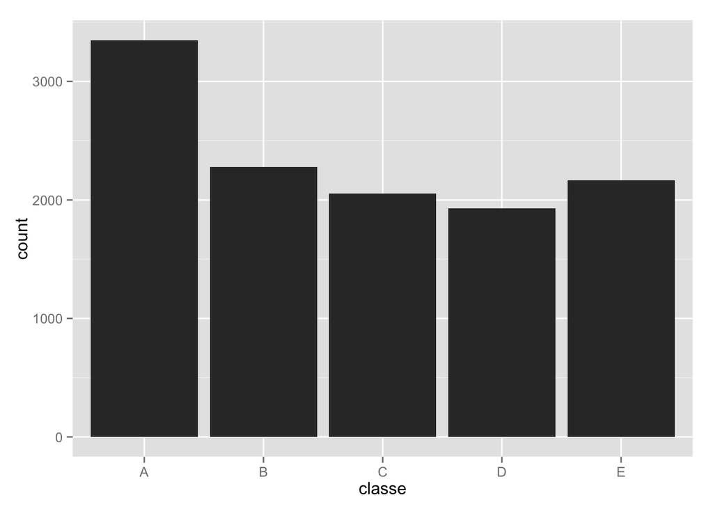

```r
qplot(classe,data=trainingML)
```

## Expectations

We expect the GBM test to perform high (above 90% accuracy) in the out of sample data, whereas the Classification Tree model will not perform as well.

## Training, Validation and Testing

Cross-validation will be applied appropriately with the calls to the train function.

### Classification Tree (RPart)

```r
modelFit.CT <- train(classe ~ ., data=trainingML,method="rpart")
pred.CT <- predict(modelFit.CT,newdata=testingML)
acc.CT<-confusionMatrix(testingML$classe,pred.CT)
acc.CT
```

```
## Confusion Matrix and Statistics
##
##           Reference
## Prediction    A    B    C    D    E
##          A 1357    3  693  171    8
##          B  229  259  725  305    0
##          C   38   28  819  483    0
##          D   66    8  389  823    0
##          E   15   10  557  200  660
##
## Overall Statistics
##
##                Accuracy : 0.4994
##                  95% CI : (0.4882, 0.5105)
##     No Information Rate : 0.4057
##     P-Value [Acc > NIR] : < 2.2e-16
##
##                   Kappa : 0.3764
##  Mcnemar's Test P-Value : < 2.2e-16
##
## Statistics by Class:
##
##                      Class: A Class: B Class: C Class: D Class: E
## Sensitivity            0.7959  0.84091   0.2573   0.4152  0.98802
## Specificity            0.8575  0.83298   0.8823   0.9210  0.89106
## Pos Pred Value         0.6080  0.17062   0.5987   0.6400  0.45770
## Neg Pred Value         0.9380  0.99226   0.6351   0.8233  0.99875
## Prevalence             0.2173  0.03926   0.4057   0.2526  0.08514
## Detection Rate         0.1730  0.03301   0.1044   0.1049  0.08412
## Detection Prevalence   0.2845  0.19347   0.1744   0.1639  0.18379
## Balanced Accuracy      0.8267  0.83694   0.5698   0.6681  0.93954
```

### Boost

```r
fitControl.gbm <- trainControl(method="cv",
                           number=5,
                           repeats=1,
                           verboseIter=FALSE)
modelFit.gbm <- train(classe ~ ., data=trainingML,method="gbm",trControl=fitControl.gbm,verbose=FALSE)
pred.gbm <- predict(modelFit.gbm,newdata=testingML)
acc.gbm<-confusionMatrix(testingML$classe,pred.gbm)
acc.gbm
```

```
## Confusion Matrix and Statistics
##
##           Reference
## Prediction    A    B    C    D    E
##          A 2197   21   10    4    0
##          B   42 1422   43    3    8
##          C    0   39 1314   14    1
##          D    3    5   53 1215   10
##          E    2   18   18   24 1380
##
## Overall Statistics
##
##                Accuracy : 0.9595
##                  95% CI : (0.9549, 0.9637)
##     No Information Rate : 0.286
##     P-Value [Acc > NIR] : < 2.2e-16
##
##                   Kappa : 0.9487
##  Mcnemar's Test P-Value : 1.429e-10
##
## Statistics by Class:
##
##                      Class: A Class: B Class: C Class: D Class: E
## Sensitivity            0.9791   0.9449   0.9138   0.9643   0.9864
## Specificity            0.9938   0.9849   0.9916   0.9892   0.9904
## Pos Pred Value         0.9843   0.9368   0.9605   0.9448   0.9570
## Neg Pred Value         0.9916   0.9869   0.9809   0.9931   0.9970
## Prevalence             0.2860   0.1918   0.1833   0.1606   0.1783
## Detection Rate         0.2800   0.1812   0.1675   0.1549   0.1759
## Detection Prevalence   0.2845   0.1935   0.1744   0.1639   0.1838
## Balanced Accuracy      0.9864   0.9649   0.9527   0.9768   0.9884
```

## Findings

The General Boosted Models method seems to yield the highest accuracy at **0.9595**. The accuracy of the Classification Tree algorithm is only **0.4994**.

## Final Testing

We will predict what the values of classe will be.

```r
pred.test <- predict(modelFit.gbm,newdata=testing)
pred.test
```

```
##  [1] B A B A A E D B A A B C B A E E A B B B
## Levels: A B C D E
```

Write to files as dictated by Coursera (using the provided code).

```r
pml_write_files = function(x){
  n = length(x)
  for(i in 1:n){
    filename = paste0("problem_id_",i,".txt")
    write.table(x[i],file=filename,quote=FALSE,row.names=FALSE,col.names=FALSE)
  }
}

pml_write_files(pred.test)
```